# EDA Assignment

Polina Sorokina

February 11, 2019

# Introduction and Data Description

For this reasearch, I was analyzing the Bike Vendor Data Set. The data consisted of 97 rows or observations and 35 columns or variables. I primarily used “dplyr” and “ggplot2” packages.

# Research Questions

Some of the research questions that this analysis will try to answer are:

- Which bike models are the most and least expensive in both Mountain and Road Category?
- How many bikes of each category are in the data set under category2?
- On average, bikes with which type of frame are more expensive?

# Data Exploration

First steps in analyzing the data set was to give myself a glims of the data set using the “head” function. The function helped to identify which type of data each column belonged to. First 4 columns were Characters, fifth “Price” was an Integral, etc.

```r
head(bikeVendors)
```

|  | model | category1 | category2 | frame | price | Albuquerque.Cycles | Ann.Arbor.Speed | Austin.Cruisers | Cincinnati.Speed | Columbus.Race.Equipment | Dallas.Cycles | Denver.Bike.Shop | Detroit.Cycles | Indianapolis.Velocipedes | Ithaca.Mountain.Climbers | Kansas.City.29ers | Las.Vegas.Cycles | Los.Angeles.Cycles | Louisville.Race.Equipment | Miami.Race.Equipment | Minneapolis.Bike.Shop | Nashville.Cruisers | New.Orleans.Velocipedes | New.York.Cycles | Oklahoma.City.Race.Equipment | Philadelphia.Bike.Shop | Phoenix.Bi.peds | Pittsburgh.Mountain.Machines | Portland.Bi.peds | … |
| --- | --- | --- | --- | --- | --- | --- | --- | --- | --- | --- | --- | --- | --- | --- | --- | --- | --- | --- | --- | --- | --- | --- | --- | --- | --- | --- | --- | --- | --- | --- |
| 1 | Bad Habit 1 | Mountain | Trail | Aluminum | 3200 | 0.017482517 | 0.006644518 | 0.008130081 | 0.00511509 | 0.010152284 | 0.012820513 | 0.01173403 | 0.009920635 | 0.006269592 | 0.01819620 | 0.01815039 | 0.001602564 | 0.006289308 | 0.007594937 | 0.004213483 | 0.01826484 | 0.00867052 | 0.018478261 | 0.007407407 | 0.012987013 | 0.024489796 | 0.01127555 | 0.01591512 | 0.01086956 | … |
| 2 | Bad Habit 2 | Mountain | Trail | Aluminum | 2660 | 0.006993007 | 0.009966777 | 0.004065041 | 0.00000000 | 0.000000000 | 0.017094017 | 0.01390700 | 0.015873016 | 0.003134796 | 0.01107595 | 0.01584558 | 0.000000000 | 0.009433962 | 0.000000000 | 0.011235955 | 0.01674277 | 0.01734104 | 0.002173913 | 0.007407407 | 0.009523810 | 0.004081633 | 0.01902748 | 0.00265252 | 0.01086956 | … |
| 3 | Beast of the East 1 | Mountain | Trail | Aluminum | 2770 | 0.010489510 | 0.014950166 | 0.008130081 | 0.00000000 | 0.000000000 | 0.004273504 | 0.01825293 | 0.011904762 | 0.009404389 | 0.02136076 | 0.01815039 | 0.001602564 | 0.025157233 | 0.000000000 | 0.014044944 | 0.01674277 | 0.00867052 | 0.008695652 | 0.017283951 | 0.024242424 | 0.000000000 | 0.01268499 | 0.00530504 | 0.01086956 | … |
| 4 | Beast of the East 2 | Mountain | Trail | Aluminum | 2130 | 0.010489510 | 0.009966777 | 0.008130081 | 0.00000000 | 0.005076142 | 0.004273504 | 0.01521078 | 0.005952381 | 0.009404389 | 0.01819620 | 0.01382887 | 0.000000000 | 0.022012579 | 0.005063291 | 0.008426966 | 0.00761035 | 0.00867052 | 0.009782609 | 0.017283951 | 0.008658009 | 0.000000000 | 0.02325581 | 0.01061008 | 0.01552795 | … |
| 5 | Beast of the East 3 | Mountain | Trail | Aluminum | 1620 | 0.003496503 | 0.003322259 | 0.000000000 | 0.00000000 | 0.002538071 | 0.004273504 | 0.01694915 | 0.011904762 | 0.000000000 | 0.01028481 | 0.01815039 | 0.003205128 | 0.000000000 | 0.005063291 | 0.004213483 | 0.01522070 | 0.02023121 | 0.004347826 | 0.004938272 | 0.005194805 | 0.020408163 | 0.01620860 | 0.00265252 | 0.02018633 | … |
| 6 | CAAD Disc Ultegra | Road | Elite Road | Aluminum | 2660 | 0.013986014 | 0.026578073 | 0.020325203 | 0.01534527 | 0.010152284 | 0.000000000 | 0.01086484 | 0.007936508 | 0.009404389 | 0.00000000 | 0.01065975 | 0.011217949 | 0.015723270 | 0.027848101 | 0.021067416 | 0.01826484 | 0.03757225 | 0.015217391 | 0.017283951 | 0.010389610 | 0.016326531 | 0.01268499 | 0.00265252 | 0.01397515 | … |

Next, I performed a simple summary analysis of the “Price” column.

```r
summary(bikeVendors$price)
```

```
##    Min. 1st Qu.  Median    Mean 3rd Qu.    Max.
##     415    1950    3200    3954    5330   12790
```

That formula has given me a basic statistic of the column. With lowest price being 415; highest 12,790; median 3,200; mean 3,954; 1st quartile 1,950; 3rd quartile 5,330.

Next, I performed a deeper analysis to answer my research questions:

### Which bike models are the most expensive and the cheapest in both Mountain and Road Category?

To answer the first question, I have decided to create a graph chart of Bike Models and their Prices.

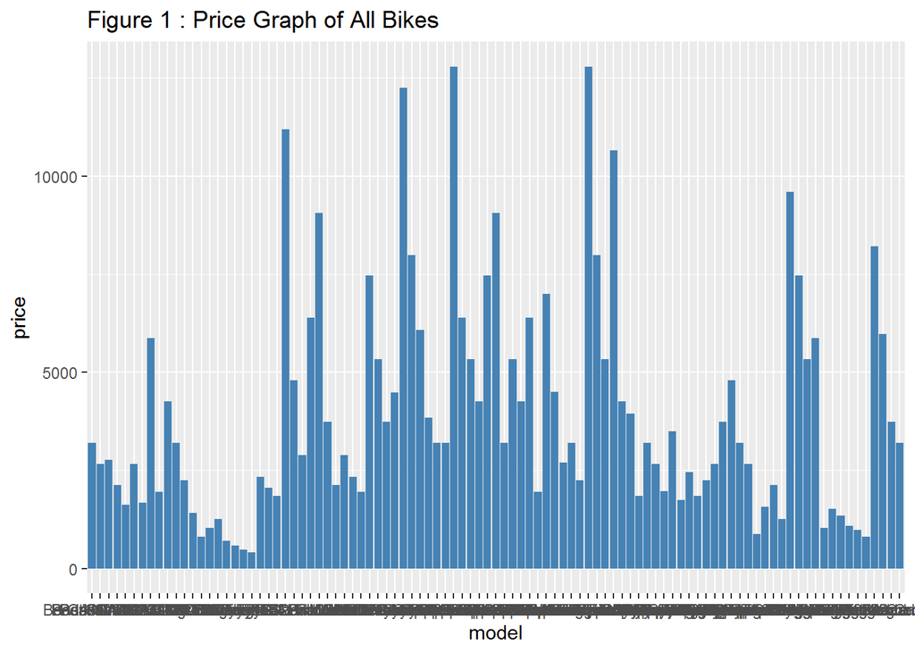

```r
ggplot(bikeVendors, aes(x=model, y=price)) + geom_bar(fill="steelblue", stat = "identity") + labs(title = "Figure 1 : Price Graph of All Bikes")
```

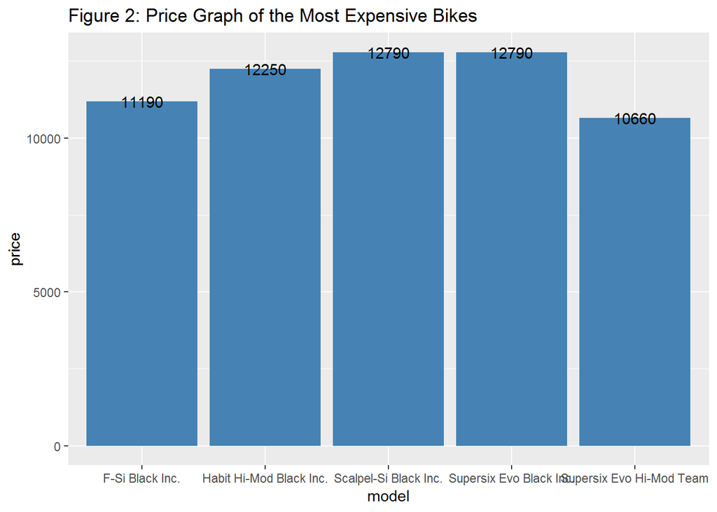

```r
expensive_bikes <- bikeVendors %>% filter(price > 10000)

ggplot(expensive_bikes, aes(x=model, y=price)) + geom_bar(fill="steelblue", stat = "identity") + geom_text(aes(label=price)) + labs(title = "Figure 2: Price Graph of the Most Expensive Bikes")
```

As you can see on the graph, the top two most expensive bike models are: “Scalpel-Si Black Inc.” and “Supersix Evo Black Inc.”, both are priced at $12,790.

I performed the same steps to identify the least expensive bikes in the market.

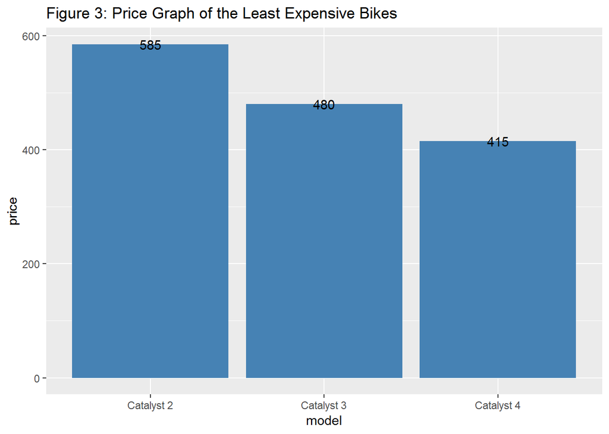

```r
cheap_bikes <- bikeVendors %>% filter(price < 600)

ggplot(cheap_bikes, aes(x=model, y=price)) + geom_bar(fill="steelblue", stat = "identity") + geom_text(aes(label=price)) + labs(title = "Figure 3: Price Graph of the Least Expensive Bikes")
```

The above graph has answered the second part of my first research question - the lease expensive bike on the market is “Catalyst 4” at $415.

```r
bikeVendors %>% filter(model == "Supersix Evo Black Inc." | model=="Supersix Evo Hi-Mod Team" | model=="Catalyst 4") %>% subset(select=c(model,category1,category2,frame))
```

|  | model | category1 | category2 | frame |
| --- | --- | --- | --- | --- |
| 1 | Catalyst 4 | Mountain | Sport | Aluminum |
| 2 | Supersix Evo Black Inc. | Road | Elite Road | Carbon |
| 3 | Supersix Evo Hi-Mod Team | Road | Elite Road | Carbon |

### How many bikes of each category are in the data set under category2?

To identify that, I have created a simple table:

```r
 bikeVendors %>% group_by(category2) %>% summarise(n=n())
```

| category2 | n |
| --- | --- |
| Cross Country Race | 19 |
| Cyclocross | 4 |
| Elite Road | 21 |
| Endurance Road | 16 |
| Fat Bike | 2 |
| Over Mountain | 8 |
| Sport | 9 |
| Trail | 13 |
| Triathalon | 5 |

Which showed that the data frame consists of 21 Elite Road Bikes; 19 Cross Country Race bikes; 16 Endurance Road bikes, etc.

### On average, bikes with which type of frame are more expensive?

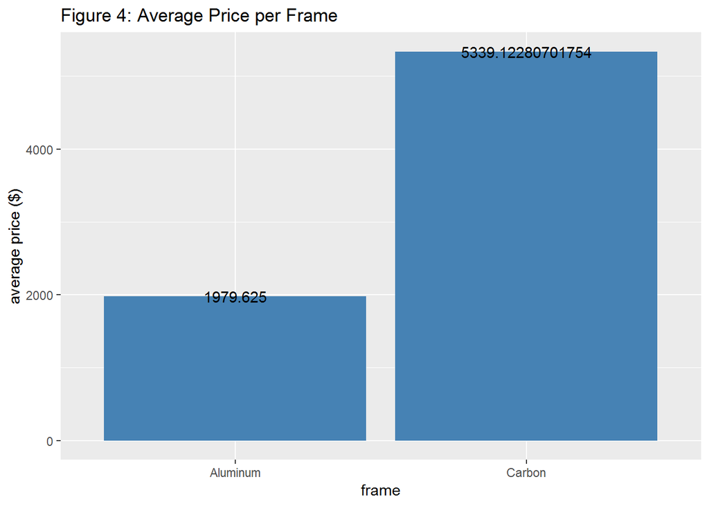

```r
average_frame <- bikeVendors %>% group_by(frame) %>% summarise(mean = mean(price))

ggplot(average_frame, aes(frame, mean)) + geom_bar(fill="steelblue", stat = "identity") + labs(title = "Figure 4: Average Price per Frame") + ylab("average price ($)") + geom_text(aes(label=mean))
```

As you can see the Carbon bikes are significantly more expensive at the average of $5,339. While the average price of aluminum bike is only $1,979.

# Conclusion

The reasearch provided me with a better understanding of the data and the relationships among different variables within the data frame. I was able to identify the most and least expensive bikes along with which category those bikes belonged to. I was able to see the category spread of the bikes and which types of bikes are more expensive.

The report is also posted here:

https://github.com/polinasorokina/dataanalytics/tree/master/Project